# Assignment 7 - Peter Cuomo

# Question 1

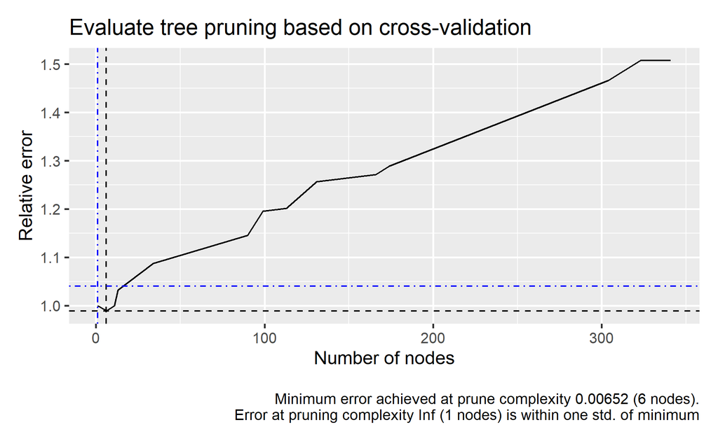

```r
result <- crtree(
  CreditCardLoanNew,
  rvar = "Noncurrent",
  evar = c("CreditGrade", "Amount", "Age", "BorrowerRate", "DebtToIncomeRatio"),
  type = "classification",
  lev = "1",
  data_filter = "Train==1"
)

plot(result, plots = "prune", custom = FALSE)
```

```r
# plot(result, orient = "TD", width = "900px") %>% render()
```

# Question 2

- Age below 4.5 years is the largest leaf with the greatest number of observations.
- The number of observations is **2,269** and the probability of the Noncurrent = 1 is **2.60%**

```r
result <- crtree(
  CreditCardLoanNew,
  rvar = "Noncurrent",
  evar = c("CreditGrade", "Amount", "Age", "BorrowerRate", "DebtToIncomeRatio"),
  type = "classification",
  lev = "1",
  nodes = 5,
  data_filter = "Train==1"
)
summary(result, prn = TRUE)
```

```
Classification tree
Data                 : CreditCardLoanNew
Filter               : Train==1
Response variable    : Noncurrent
Level                : 1 in Noncurrent
Explanatory variables: CreditGrade, Amount, Age, BorrowerRate, DebtToIncomeRatio
Complexity parameter : 0.001
Minimum observations : 2
Maximum nr. nodes    : 5 out of 341
Nr obs               : 4,400

node), split, n, loss, yval, (yprob)
      * denotes terminal node

 1) root 4400 343 0 (0.07795455 0.92204545)
   2) Age>=4.5 2131 284 0 (0.13327076 0.86672924)
     4) BorrowerRate>=0.227 775 199 0 (0.25677419 0.74322581)
       8) BorrowerRate>=0.31625 40  17 1 (0.57500000 0.42500000)
        16) DebtToIncomeRatio< 0.1615 22   4 1 (0.81818182 0.18181818) *
        17) DebtToIncomeRatio>=0.1615 18   5 0 (0.27777778 0.72222222) *
       9) BorrowerRate< 0.31625 735 176 0 (0.23945578 0.76054422) *
     5) BorrowerRate< 0.227 1356  85 0 (0.06268437 0.93731563) *
   3) Age< 4.5 2269  59 0 (0.02600264 0.97399736) *
```

```r
# plot(result, plots = "prune", custom = FALSE)
plot(result, orient = "TD", width = "900px") %>% render()
```

[interactive chart not shown]

# Question 3

```r
result <- explore(
  CreditCardLoanNew,
  vars = c("pred_crtree1", "pred_crtree2"),
  fun = c("mean", "sd"),
  data_filter = "Train==1",
  nr = 2
)
summary(result)
```

```
Explore
Data        : CreditCardLoanNew
Filter      : Train==1
Functions   : mean, sd
Top         : Function

     variable  mean    sd
 pred_crtree1 0.078 0.093
 pred_crtree2 0.078 0.238
```

```r
# dtab(result) %>% render()
```

# Question 4

- **Pred_crtree2** produces better cumulative gains on the training set.

```r
result <- evalbin(
  CreditCardLoanNew,
  pred = c("pred_crtree1", "pred_crtree2"),
  rvar = "Noncurrent",
  lev = "1",
  train = "Training",
  data_filter = "Train==1"
)
summary(result, prn = FALSE)
```

```
Evaluate predictions for binary response models
Data        : CreditCardLoanNew
Filter      : Train==1
Results for : Training
Predictors  : pred_crtree1, pred_crtree2
Response    : Noncurrent
Level       : 1 in Noncurrent
Bins        : 10
Cost:Margin : 1 : 2
```

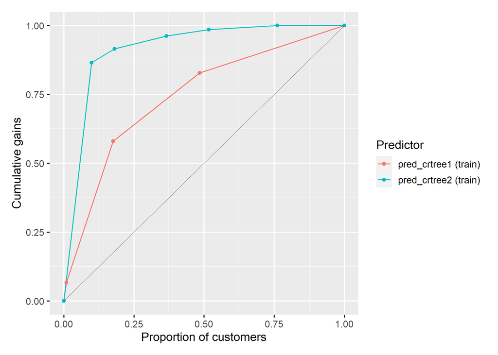

```r
plot(result, plots = "gains", custom = FALSE)
```

- **Pred_crtree1** produces better cumulative gains on the test set.

```r
result <- evalbin(
  CreditCardLoanNew,
  pred = c("pred_crtree1", "pred_crtree2"),
  rvar = "Noncurrent",
  lev = "1",
  train = "Test",
  data_filter = "Train==1"
)
summary(result, prn = FALSE)
```

```
Evaluate predictions for binary response models
Data        : CreditCardLoanNew
Filter      : Train==1
Results for : Test
Predictors  : pred_crtree1, pred_crtree2
Response    : Noncurrent
Level       : 1 in Noncurrent
Bins        : 10
Cost:Margin : 1 : 2
```

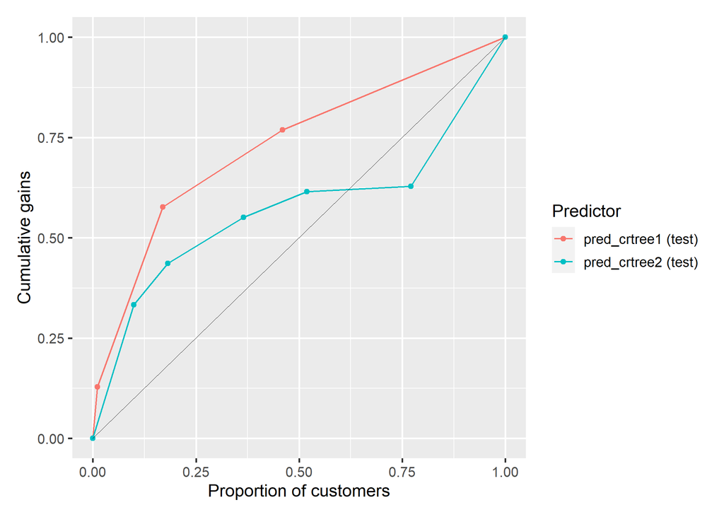

```r
plot(result, plots = "gains", custom = FALSE)
```

# Question 5

- **Pred_crtree2** has a higher AUC for the training set.

```r
result <- confusion(
  CreditCardLoanNew,
  pred = c("pred_crtree1", "pred_crtree2"),
  rvar = "Noncurrent",
  lev = "1",
  margin = 10,
  train = "Training",
  data_filter = "Train==1"
)
summary(result)
```

```
Confusion matrix
Data       : CreditCardLoanNew
Filter     : Train==1
Results for: Training
Predictors : pred_crtree1, pred_crtree2
Response   : Noncurrent
Level      : 1 in Noncurrent
Cost:Margin: 1 : 10

     Type    Predictor  TP  FP    TN  FN total   TPR   TNR precision Fscore
 Training pred_crtree1 199 576 3,481 144 4,400 0.580 0.858     0.257  0.356
 Training pred_crtree2 293  97 3,960  50 4,400 0.854 0.976     0.751  0.799

     Type    Predictor accuracy kappa profit index  ROME contact   AUC
 Training pred_crtree1    0.836 0.278  1,215 0.478 1.568   0.176 0.763
 Training pred_crtree2    0.967 0.781  2,540 1.000 6.513   0.089 0.968
```

- **Pred_crtree1** has a higher AUC for the test set.

```r
result <- confusion(
  CreditCardLoanNew,
  pred = c("pred_crtree1", "pred_crtree2"),
  rvar = "Noncurrent",
  lev = "1",
  margin = 10,
  train = "Test",
  data_filter = "Train==1"
)
summary(result)
```

```
Confusion matrix
Data       : CreditCardLoanNew
Filter     : Train==1
Results for: Test
Predictors : pred_crtree1, pred_crtree2
Response   : Noncurrent
Level      : 1 in Noncurrent
Cost:Margin: 1 : 10

 Type    Predictor TP  FP  TN FN total   TPR   TNR precision Fscore
 Test pred_crtree1 45 141 881 33 1,100 0.577 0.862     0.242  0.341
 Test pred_crtree2 23  77 945 55 1,100 0.295 0.925     0.230  0.258

 Type    Predictor accuracy kappa profit index  ROME contact   AUC
 Test pred_crtree1    0.842 0.268    264 1.000 1.419   0.169 0.748
 Test pred_crtree2    0.880 0.194    130 0.492 1.300   0.091 0.573
```

# Question 6

- For pred_crtree1:

Accuracy = (True Positive + True Negative)/Total

```
     = (45+881)/1100

     = 84.18%
```

Precision = True Positive/Predicted Positive (False Positive+True Positive)

```
     = 45/(141+45)

     = 24.19%
```

# Question 7

- Predicted Negative = False Negative + True Negative

  ```
                 = 881 + 33

                 = 914
  ```

- **914** loans will be approved
- 33 out of the 914 predicted negative loans will actually be Noncurrent. The percentage is **3.61%**

# Question 8

- **Pred_logit** produces better cumulative gains for the test set.

```r
result <- evalbin(
  CreditCardLoanNew,
  pred = c("pred_crtree1", "pred_logit"),
  rvar = "Noncurrent",
  lev = "1",
  margin = 10,
  train = "Test",
  data_filter = "Train==1"
)
summary(result, prn = FALSE)
```

```
Evaluate predictions for binary response models
Data        : CreditCardLoanNew
Filter      : Train==1
Results for : Test
Predictors  : pred_crtree1, pred_logit
Response    : Noncurrent
Level       : 1 in Noncurrent
Bins        : 10
Cost:Margin : 1 : 10
```

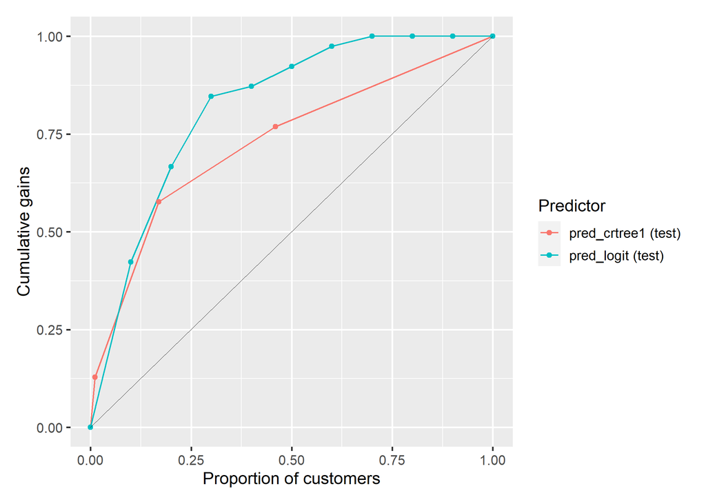

```r
plot(result, plots = "gains", custom = FALSE)
```

- **Pred_logit** has the higher AUC for the test set.

```r
result <- confusion(
  CreditCardLoanNew,
  pred = c("pred_crtree1", "pred_logit"),
  rvar = "Noncurrent",
  lev = "1",
  margin = 10,
  train = "Test",
  data_filter = "Train==1"
)
summary(result)
```

```
Confusion matrix
Data       : CreditCardLoanNew
Filter     : Train==1
Results for: Test
Predictors : pred_crtree1, pred_logit
Response   : Noncurrent
Level      : 1 in Noncurrent
Cost:Margin: 1 : 10

 Type    Predictor TP  FP  TN FN total   TPR   TNR precision Fscore
 Test pred_crtree1 45 141 881 33 1,100 0.577 0.862     0.242  0.341
 Test   pred_logit 58 196 826 20 1,100 0.744 0.808     0.228  0.349

 Type    Predictor accuracy kappa profit index  ROME contact   AUC
 Test pred_crtree1    0.842 0.268    264 0.810 1.419   0.169 0.748
 Test   pred_logit    0.804 0.270    326 1.000 1.283   0.231 0.852
```